# DAV5303 HW_5

Rob Rolleston

15 FEB 2022

DUE FEB-21 8:00PM EST  
*NOTE:* Your hw solution may be shared with the class.

## What is being assessed ?

- Your ability to
  - Calculate and plot Confidence of Mean of a sample
  - Use an .RMD to produce an .HTML with stylized summary statistics and charts
- I should be able
  - examine the files
  - (optional: execute your .R file and reproduce your answers)
  - knit your .RMD file and create a .html file
  - read about what you did.

## Submission Details

- A .ZIP file with three files contained within a directory:
  0. (Optional: your .R file used to fill in the chunks of the .RMD)
  1. your .RMD file
  2. your final .html file
- Naming convention for directory & .ZIP
  - RobRolleston_HW5_2022-02-21.zip

## 1) Histogram and mean of population

Use the data set `gcookbook::heightweight` as the ‘population’

1.1) Calculate the count, mean and sd of the population weightLb and commmunicate the values in the document.

1.2) Plot a density histogram of the population weightLb, and draw a heavy black dashed vertical line at the location of the mean and use white bars with black edges for the histogram.

## 2) Histogram and mean of sample

2.1) Now create a random sample of 15 from the population, and calculate the mean, sd, and .90 and .99 CI of the mean predicted from the sample weights. **NOTE:** If you use `set.seed()` you will always get the same sample

2.2) Add to the plot from 1.2 (if you can’t do 1.2, then create this as a new plot) , by graphing properties of the sample

- density histogram in transparent red
- sample mean as a red dotted vertical line
- .90 and .99 CI bounds as green and blue solid vertical lines respectively

Something like this, but your data and styling may differ; especially since this is unattractive, IMHO. Maybe a `geom_density()` would work better, or maybe a `geom_histogram(... position="dodge")`. See what you can do.

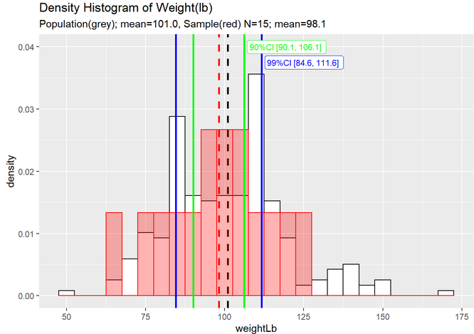

**As always…** If you are stuck, lost, confused, frustrated, etc. … Contact me. I am here to help